# Causal Thinking in Longitudinal Data Analysis

Intro to longitudinal identification, and some econometric ideas

Christian Testa

ctesta@hsph.harvard.edu

Department of Biostatistics, HSPH

November 10, 2026

## Intro to Longitudinal Causal Inference

[figure not shown]

what arrows are needed? what situation are we trying to describe?

## Origins of Observational Causal Inference

On the tails of wide acceptance of smoking $\to$ lung cancer, James Robins invents a lot of what we use today.

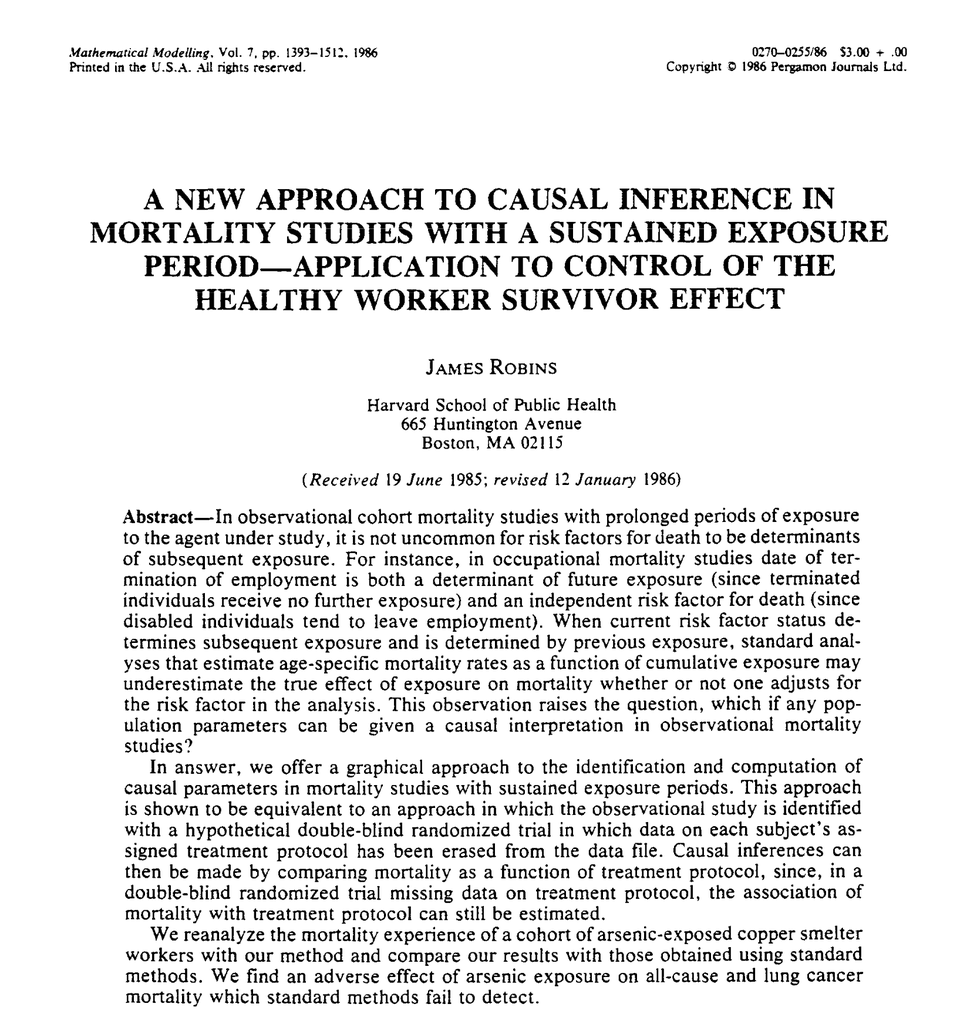

## Then the HIV/AIDS crisis happens

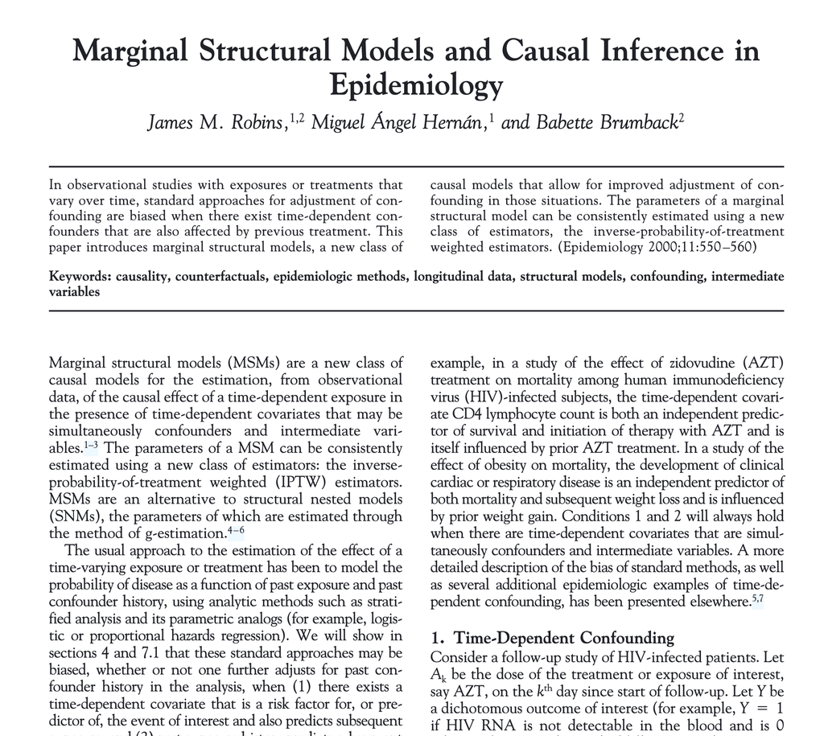

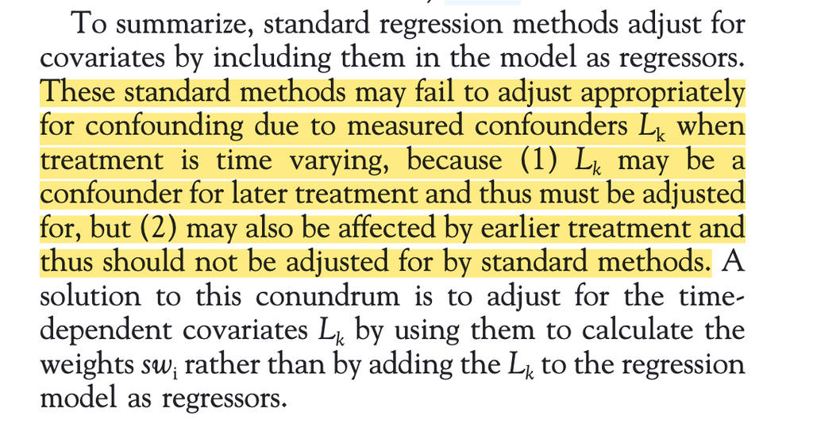

## But what did it mean for HIV/AIDS trials?

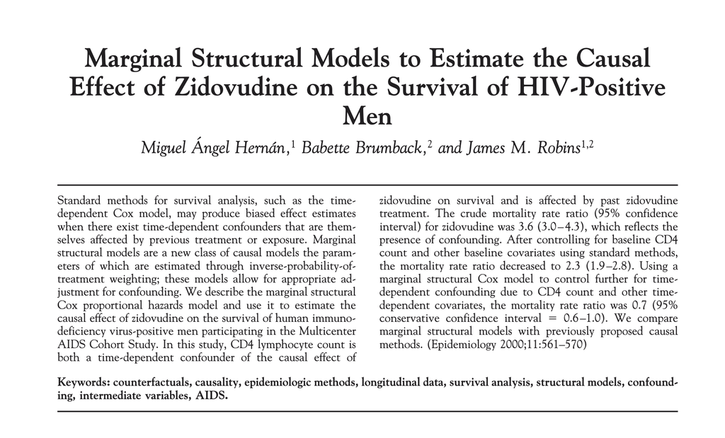

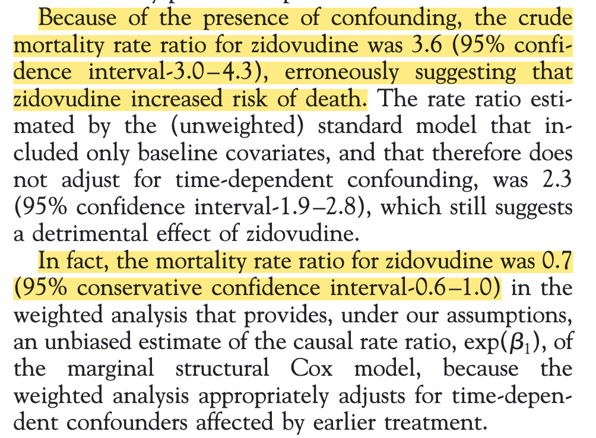

## Let’s take a step back

- It takes some effort to learn longitudinal g-methods and implement them well.
- There are yet more causal estimands in the longitudinal setting.
- How can you do the best job you can on a longitudinal data analysis for this class?
- Maybe the work you do will/won’t be fully causal, but it can be the stepping stone to even more rigorous work and public health advocacy.

## Let’s take a look at some causal-adjacent concepts

- Interrupted Time-Series
- Parallel Trends
- . . .

## References

- Hernán and Robins, What If Part III - Robins & Hernán, *Estimation of the causal effects of time-varying exposures* Ch. 23 in Longitudinal Data Analysis, 2009. - Robins, Hernán, Brumback, *Marginal structural models and causal inference in epidemiology.* 2000

- Suicides associated with the 2008-10 economic recession in England: time trend analysis https://www.bmj.com/content/345/bmj.e5142
- Effects of Medicaid Drug-Payment Limits on Admission to Hospitals and Nursing Homes https://www.nejm.org/doi/10.1056/NEJM199110103251505
- Decline in pneumonia admissions after routine childhood immunisation with pneumococcal conjugate vaccine in the USA: a time-series analysis https://www.thelancet.com/journals/lancet/article/PIIS0140-6736(07)60564-9/abstract
- Short term impact of smoke-free legislation in England: retrospective analysis of hospital admissions for myocardial infarction https://www.bmj.com/content/bmj/340/bmj.c2161.full.pdf
- Long term effect of reduced pack sizes of paracetamol on poisoning deaths and liver transplant activity in England and Wales: interrupted time series analyses https://pubmed.ncbi.nlm.nih.gov/23393081/
- Evaluating the impact of “stand your ground” https://www.ag-myresearch.com/uploads/1/3/8/6/13864925/2020_degliesposti_ije.pdf
- Asssociation between the release of Netflix’ 13 reasons why https://www.jaacap.org/article/s0890-8567(19)30288-6/fulltext#fig1
- Can synthetic controls improve causal inference in interrupted time series evaluations of public health interventions? https://www.ag-myresearch.com/uploads/1/3/8/6/13864925/2020_degliesposti_ije.pdf